# Overview

Dataset info

| Number of variables | 22 |
| --- | --- |
| Number of observations | 20153 |
| Missing cells | 2 (< 0.1%) |
| Duplicate rows | 0 (0.0%) |
| Total size in memory | 3.4 MiB |
| Average record size in memory | 176.0 B |

Variables types

| Numeric | 4 |
| --- | --- |
| Categorical | 5 |
| Boolean | 1 |
| Date | 0 |
| URL | 0 |
| Text (Unique) | 0 |
| Rejected | 12 |
| Unsupported | 0 |

Warnings

| `High_Wind_NE` has constant value "-999" | Rejected |
| --- | --- |
| `High_Wind_NW` has constant value "-999.0" | Rejected |
| `High_Wind_SW` has constant value "-999.0" | Rejected |
| `ID` has a high cardinality: 736 distinct values | Warning |
| `Latitude` has a high cardinality: 541 distinct values | Warning |
| `Longitude` has a high cardinality: 879 distinct values | Warning |
| `Low_Wind_NE` has constant value "-999" | Rejected |
| `Low_Wind_NW` has constant value "-999" | Rejected |
| `Low_Wind_SE` has constant value "-999" | Rejected |
| `Low_Wind_SW` has constant value "-999" | Rejected |
| `Moderate_Wind_NE` has constant value "-999" | Rejected |
| `Moderate_Wind_NW` has constant value "-999" | Rejected |
| `Moderate_Wind_SE` has constant value "-999" | Rejected |
| `Moderate_Wind_SW` has constant value "-999" | Rejected |
| `Name` has constant value " UNNAMED" | Rejected |
| `Time` has 4893 (24.3%) zeros | Zeros |

# Variables

Date  
Numeric

| Distinct count | 4342 |
| --- | --- |
| Unique (%) | 21.5% |
| Missing (%) | 0.0% |
| Missing (n) | 0 |
| Infinite (%) | 0.0% |
| Infinite (n) | 0 |

| Mean | 1.9034e+07 |
| --- | --- |
| Minimum | 1.8511e+07 |
| Maximum | 1.9431e+07 |
| Zeros (%) | 0.0% |

[figure not shown]

Toggle details

**Statistics**

Quantile statistics

| Minimum | 1.8511e+07 |
| --- | --- |
| 5-th percentile | 1.8611e+07 |
| Q1 | 1.8861e+07 |
| Median | 1.9021e+07 |
| Q3 | 1.9261e+07 |
| 95-th percentile | 1.9391e+07 |
| Maximum | 1.9431e+07 |
| Range | 9.2038e+05 |
| Interquartile range | 4.001e+05 |

Descriptive statistics

| Standard deviation | 2.4332e+05 |
| --- | --- |
| Coef of variation | 0.012783 |
| Kurtosis | -0.98272 |
| Mean | 1.9034e+07 |
| MAD | 2.0701e+05 |
| Skewness | -0.15477 |
| Sum | 3.836e+11 |
| Variance | 5.9204e+10 |
| Memory size | 157.5 KiB |

**Histogram**

[figure not shown]

**Common Values**

| Value | Count | Frequency (%) |  |
| --- | --- | --- | --- |
| 1.9001e+07 | 17 | < 0.1% |  |
| 1.9001e+07 | 16 | < 0.1% |  |
| 1.8931e+07 | 16 | < 0.1% |  |
| 1.8931e+07 | 16 | < 0.1% |  |
| 1.8931e+07 | 16 | < 0.1% |  |
| 1.9001e+07 | 16 | < 0.1% |  |
| 1.9261e+07 | 16 | < 0.1% |  |
| 1.8931e+07 | 16 | < 0.1% |  |
| 1.8931e+07 | 16 | < 0.1% |  |
| 1.8931e+07 | 16 | < 0.1% |  |
| Other values (4332) | 19992 | > 99.9% |  |

**Extreme Values**

Minimum 5 values

| Value | Count | Frequency (%) |  |
| --- | --- | --- | --- |
| 1.8511e+07 | 5 | < 0.1% |  |
| 1.8511e+07 | 4 | < 0.1% |  |
| 1.8511e+07 | 4 | < 0.1% |  |
| 1.8511e+07 | 1 | < 0.1% |  |
| 1.8511e+07 | 1 | < 0.1% |  |

Maximum 5 values

| Value | Count | Frequency (%) |  |
| --- | --- | --- | --- |
| 1.9431e+07 | 5 | < 0.1% |  |
| 1.9431e+07 | 7 | < 0.1% |  |
| 1.9431e+07 | 4 | < 0.1% |  |
| 1.9431e+07 | 4 | < 0.1% |  |
| 1.9431e+07 | 3 | < 0.1% |  |

Event  
Categorical

| Distinct count | 2 |
| --- | --- |
| Unique (%) | < 0.1% |
| Missing (%) | 0.0% |
| Missing (n) | 0 |

|  | 19799 |
| --- | --- |
| L | 354 |

Toggle details

**Frequency**

| Value | Count | Frequency (%) |  |
| --- | --- | --- | --- |
|  | 19799 | > 99.9% |  |
| L | 354 | < 0.1% |  |

**Composition**

| Max length | 2 |
| --- | --- |
| Mean length | 2 |
| Min length | 2 |
| Contains chars | True |
| Contains digits | False |
| Contains spaces | True |
| Contains non-words | True |

High_Wind_NE  
Constant

*This variable is constant and should be ignored for analysis*

| Constant value | -999 |
| --- | --- |

High_Wind_NW  
Constant

*This variable is constant and should be ignored for analysis*

| Constant value | -999.0 |
| --- | --- |

High_Wind_SE  
Boolean

| Distinct count | 2 |
| --- | --- |
| Unique (%) | < 0.1% |
| Missing (%) | 0.0% |
| Missing (n) | 0 |

| -999 | 20152 |
| --- | --- |
| -9 | 1 |

Toggle details

| Value | Count | Frequency (%) |  |
| --- | --- | --- | --- |
| -999 | 20152 | > 99.9% |  |
| -9 | 1 | < 0.1% |  |

High_Wind_SW  
Constant

*This variable is constant and should be ignored for analysis*

| Constant value | -999.0 |
| --- | --- |

ID  
Categorical

| Distinct count | 736 |
| --- | --- |
| Unique (%) | < 0.1% |
| Missing (%) | 0.0% |
| Missing (n) | 0 |

| AL031899 | 133 |
| --- | --- |
| AL041926 | 95 |
| AL091893 | 84 |
| Other values (733) | 19841 |

Toggle details

**Frequency**

| Value | Count | Frequency (%) |  |
| --- | --- | --- | --- |
| AL031899 | 133 | < 0.1% |  |
| AL041926 | 95 | < 0.1% |  |
| AL091893 | 84 | < 0.1% |  |
| AL021930 | 81 | < 0.1% |  |
| AL011900 | 81 | < 0.1% |  |
| AL061893 | 75 | < 0.1% |  |
| AL021915 | 75 | < 0.1% |  |
| AL041906 | 74 | < 0.1% |  |
| AL041932 | 73 | < 0.1% |  |
| AL131936 | 71 | < 0.1% |  |
| Other values (726) | 19311 | > 99.9% |  |

**Composition**

| Max length | 8 |
| --- | --- |
| Mean length | 8 |
| Min length | 8 |
| Contains chars | True |
| Contains digits | True |
| Contains spaces | False |
| Contains non-words | False |

Latitude  
Categorical

| Distinct count | 541 |
| --- | --- |
| Unique (%) | < 0.1% |
| Missing (%) | 0.0% |
| Missing (n) | 0 |

| 29.0N | 145 |
| --- | --- |
| 32.5N | 138 |
| 27.0N | 136 |
| Other values (538) | 19734 |

Toggle details

**Frequency**

| Value | Count | Frequency (%) |  |
| --- | --- | --- | --- |
| 29.0N | 145 | < 0.1% |  |
| 32.5N | 138 | < 0.1% |  |
| 27.0N | 136 | < 0.1% |  |
| 32.0N | 135 | < 0.1% |  |
| 33.0N | 135 | < 0.1% |  |
| 28.0N | 134 | < 0.1% |  |
| 20.0N | 131 | < 0.1% |  |
| 26.0N | 130 | < 0.1% |  |
| 18.0N | 129 | < 0.1% |  |
| 21.0N | 124 | < 0.1% |  |
| Other values (531) | 18816 | 93.4% |  |

**Composition**

| Max length | 5 |
| --- | --- |
| Mean length | 4.9981 |
| Min length | 4 |
| Contains chars | True |
| Contains digits | True |
| Contains spaces | False |
| Contains non-words | True |

Longitude  
Categorical

| Distinct count | 879 |
| --- | --- |
| Unique (%) | < 0.1% |
| Missing (%) | 0.0% |
| Missing (n) | 0 |

| 73.5W | 105 |
| --- | --- |
| 75.0W | 98 |
| 68.0W | 93 |
| Other values (876) | 19857 |

Toggle details

**Frequency**

| Value | Count | Frequency (%) |  |
| --- | --- | --- | --- |
| 73.5W | 105 | < 0.1% |  |
| 75.0W | 98 | < 0.1% |  |
| 68.0W | 93 | < 0.1% |  |
| 70.0W | 91 | < 0.1% |  |
| 79.0W | 88 | < 0.1% |  |
| 84.0W | 85 | < 0.1% |  |
| 77.0W | 85 | < 0.1% |  |
| 72.5W | 85 | < 0.1% |  |
| 69.0W | 85 | < 0.1% |  |
| 65.0W | 84 | < 0.1% |  |
| Other values (869) | 19254 | > 99.9% |  |

**Composition**

| Max length | 6 |
| --- | --- |
| Mean length | 5.0012 |
| Min length | 4 |
| Contains chars | True |
| Contains digits | True |
| Contains spaces | False |
| Contains non-words | True |

Low_Wind_NE  
Constant

*This variable is constant and should be ignored for analysis*

| Constant value | -999 |
| --- | --- |

Low_Wind_NW  
Constant

*This variable is constant and should be ignored for analysis*

| Constant value | -999 |
| --- | --- |

Low_Wind_SE  
Constant

*This variable is constant and should be ignored for analysis*

| Constant value | -999 |
| --- | --- |

Low_Wind_SW  
Constant

*This variable is constant and should be ignored for analysis*

| Constant value | -999 |
| --- | --- |

Maximum_Wind  
Numeric

| Distinct count | 29 |
| --- | --- |
| Unique (%) | < 0.1% |
| Missing (%) | 0.0% |
| Missing (n) | 0 |
| Infinite (%) | 0.0% |
| Infinite (n) | 0 |

| Mean | 58.707 |
| --- | --- |
| Minimum | 15 |
| Maximum | 160 |
| Zeros (%) | 0.0% |

[figure not shown]

Toggle details

**Statistics**

Quantile statistics

| Minimum | 15 |
| --- | --- |
| 5-th percentile | 30 |
| Q1 | 40 |
| Median | 55 |
| Q3 | 75 |
| 95-th percentile | 100 |
| Maximum | 160 |
| Range | 145 |
| Interquartile range | 35 |

Descriptive statistics

| Standard deviation | 23.166 |
| --- | --- |
| Coef of variation | 0.39459 |
| Kurtosis | -0.1478 |
| Mean | 58.707 |
| MAD | 19.338 |
| Skewness | 0.6775 |
| Sum | 1.1831e+06 |
| Variance | 536.65 |
| Memory size | 157.5 KiB |

**Histogram**

[figure not shown]

**Common Values**

| Value | Count | Frequency (%) |  |
| --- | --- | --- | --- |
| 50 | 2334 | 11.6% |  |
| 40 | 2333 | 11.6% |  |
| 35 | 2123 | 10.5% |  |
| 70 | 1864 | 9.2% |  |
| 60 | 1658 | 8.2% |  |
| 30 | 1385 | 6.9% |  |
| 45 | 1262 | 6.3% |  |
| 80 | 1113 | 5.5% |  |
| 90 | 1013 | 5.0% |  |
| 85 | 928 | < 0.1% |  |
| Other values (19) | 4140 | 20.5% |  |

**Extreme Values**

Minimum 5 values

| Value | Count | Frequency (%) |  |
| --- | --- | --- | --- |
| 15 | 3 | < 0.1% |  |
| 20 | 64 | < 0.1% |  |
| 25 | 543 | < 0.1% |  |
| 30 | 1385 | 6.9% |  |
| 35 | 2123 | 10.5% |  |

Maximum 5 values

| Value | Count | Frequency (%) |  |
| --- | --- | --- | --- |
| 160 | 3 | < 0.1% |  |
| 150 | 4 | < 0.1% |  |
| 145 | 7 | < 0.1% |  |
| 140 | 18 | < 0.1% |  |
| 135 | 22 | < 0.1% |  |

Minimum_Pressure  
Numeric

| Distinct count | 87 |
| --- | --- |
| Unique (%) | < 0.1% |
| Missing (%) | 0.0% |
| Missing (n) | 0 |
| Infinite (%) | 0.0% |
| Infinite (n) | 0 |

| Mean | -951.56 |
| --- | --- |
| Minimum | -999 |
| Maximum | 1009 |
| Zeros (%) | 0.0% |

[figure not shown]

Toggle details

**Statistics**

Quantile statistics

| Minimum | -999 |
| --- | --- |
| 5-th percentile | -999 |
| Q1 | -999 |
| Median | -999 |
| Q3 | -999 |
| 95-th percentile | -999 |
| Maximum | 1009 |
| Range | 2008 |
| Interquartile range | 0 |

Descriptive statistics

| Standard deviation | 302.11 |
| --- | --- |
| Coef of variation | -0.31749 |
| Kurtosis | 36.608 |
| Mean | -951.56 |
| MAD | 92.591 |
| Skewness | 6.2128 |
| Sum | -1.9177e+07 |
| Variance | 91271 |
| Memory size | 157.5 KiB |

**Histogram**

[figure not shown]

**Common Values**

| Value | Count | Frequency (%) |  |
| --- | --- | --- | --- |
| -999 | 19668 | > 99.9% |  |
| 975 | 13 | < 0.1% |  |
| 979 | 13 | < 0.1% |  |
| 950 | 12 | < 0.1% |  |
| 955 | 12 | < 0.1% |  |
| 1004 | 12 | < 0.1% |  |
| 972 | 12 | < 0.1% |  |
| 970 | 12 | < 0.1% |  |
| 963 | 10 | < 0.1% |  |
| 976 | 10 | < 0.1% |  |
| Other values (77) | 379 | < 0.1% |  |

**Extreme Values**

Minimum 5 values

| Value | Count | Frequency (%) |  |
| --- | --- | --- | --- |
| -999 | 19668 | > 99.9% |  |
| 892 | 2 | < 0.1% |  |
| 910 | 1 | < 0.1% |  |
| 918 | 1 | < 0.1% |  |
| 924 | 3 | < 0.1% |  |

Maximum 5 values

| Value | Count | Frequency (%) |  |
| --- | --- | --- | --- |
| 1009 | 1 | < 0.1% |  |
| 1008 | 5 | < 0.1% |  |
| 1007 | 6 | < 0.1% |  |
| 1006 | 6 | < 0.1% |  |
| 1005 | 5 | < 0.1% |  |

Moderate_Wind_NE  
Constant

*This variable is constant and should be ignored for analysis*

| Constant value | -999 |
| --- | --- |

Moderate_Wind_NW  
Constant

*This variable is constant and should be ignored for analysis*

| Constant value | -999 |
| --- | --- |

Moderate_Wind_SE  
Constant

*This variable is constant and should be ignored for analysis*

| Constant value | -999 |
| --- | --- |

Moderate_Wind_SW  
Constant

*This variable is constant and should be ignored for analysis*

| Constant value | -999 |
| --- | --- |

Name  
Constant

*This variable is constant and should be ignored for analysis*

| Constant value | UNNAMED |
| --- | --- |

Status  
Categorical

| Distinct count | 4 |
| --- | --- |
| Unique (%) | < 0.1% |
| Missing (%) | 0.0% |
| Missing (n) | 0 |

| TS | 8942 |
| --- | --- |
| HU | 7503 |
| EX | 1922 |

Toggle details

**Frequency**

| Value | Count | Frequency (%) |  |
| --- | --- | --- | --- |
| TS | 8942 | 44.4% |  |
| HU | 7503 | 37.2% |  |
| EX | 1922 | 9.5% |  |
| TD | 1786 | 8.9% |  |

**Composition**

| Max length | 3 |
| --- | --- |
| Mean length | 3 |
| Min length | 3 |
| Contains chars | True |
| Contains digits | False |
| Contains spaces | True |
| Contains non-words | True |

Time  
Numeric

| Distinct count | 24 |
| --- | --- |
| Unique (%) | < 0.1% |
| Missing (%) | 0.0% |
| Missing (n) | 0 |
| Infinite (%) | 0.0% |
| Infinite (n) | 0 |

| Mean | 909.25 |
| --- | --- |
| Minimum | 0 |
| Maximum | 2300 |
| Zeros (%) | 24.3% |

[figure not shown]

Toggle details

**Statistics**

Quantile statistics

| Minimum | 0 |
| --- | --- |
| 5-th percentile | 0 |
| Q1 | 600 |
| Median | 1200 |
| Q3 | 1800 |
| 95-th percentile | 1800 |
| Maximum | 2300 |
| Range | 2300 |
| Interquartile range | 1200 |

Descriptive statistics

| Standard deviation | 670.36 |
| --- | --- |
| Coef of variation | 0.73727 |
| Kurtosis | -1.3399 |
| Mean | 909.25 |
| MAD | 598.38 |
| Skewness | -0.008165 |
| Sum | 1.8324e+07 |
| Variance | 4.4938e+05 |
| Memory size | 157.5 KiB |

**Histogram**

[figure not shown]

**Common Values**

| Value | Count | Frequency (%) |  |
| --- | --- | --- | --- |
| 1200 | 5038 | 25.0% |  |
| 600 | 4961 | 24.6% |  |
| 1800 | 4959 | 24.6% |  |
| 0 | 4893 | 24.3% |  |
| 2100 | 26 | < 0.1% |  |
| 1300 | 19 | < 0.1% |  |
| 1000 | 18 | < 0.1% |  |
| 800 | 18 | < 0.1% |  |
| 1600 | 18 | < 0.1% |  |
| 2200 | 18 | < 0.1% |  |
| Other values (14) | 185 | < 0.1% |  |

**Extreme Values**

Minimum 5 values

| Value | Count | Frequency (%) |  |
| --- | --- | --- | --- |
| 0 | 4893 | 24.3% |  |
| 100 | 16 | < 0.1% |  |
| 200 | 13 | < 0.1% |  |
| 300 | 11 | < 0.1% |  |
| 400 | 15 | < 0.1% |  |

Maximum 5 values

| Value | Count | Frequency (%) |  |
| --- | --- | --- | --- |
| 2300 | 14 | < 0.1% |  |
| 2200 | 18 | < 0.1% |  |
| 2100 | 26 | < 0.1% |  |
| 2000 | 14 | < 0.1% |  |
| 1900 | 9 | < 0.1% |  |

# Correlations

**Pearson**

[figure not shown]

**Spearman**

[figure not shown]

**Kendall**

[figure not shown]

**Phik**

[figure not shown]

**Recoded**

[figure not shown]

# Missing values

## Matrix

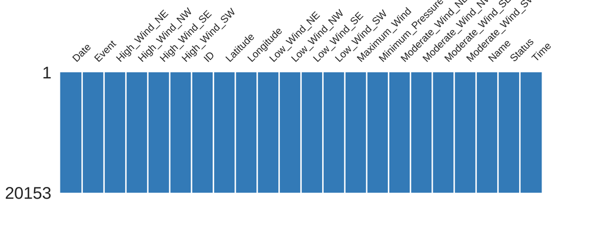

## Count

[figure not shown]

## Heatmap

[figure not shown]

## Dendrogram

[figure not shown]

# Sample

## First rows

|  | Date | Event | High_Wind_NE | High_Wind_NW | High_Wind_SE | High_Wind_SW | ID | Latitude | Longitude | Low_Wind_NE | Low_Wind_NW | Low_Wind_SE | Low_Wind_SW | Maximum_Wind | Minimum_Pressure | Moderate_Wind_NE | Moderate_Wind_NW | Moderate_Wind_SE | Moderate_Wind_SW | Name | Status | Time |
| --- | --- | --- | --- | --- | --- | --- | --- | --- | --- | --- | --- | --- | --- | --- | --- | --- | --- | --- | --- | --- | --- | --- |
| 0 | 18510625 |  | -999 | -999.0 | -999 | -999.0 | AL011851 | 28.0N | 94.8W | -999 | -999 | -999 | -999 | 80 | -999 | -999 | -999 | -999 | -999 | UNNAMED | HU | 0 |
| 1 | 18510625 |  | -999 | -999.0 | -999 | -999.0 | AL011851 | 28.0N | 95.4W | -999 | -999 | -999 | -999 | 80 | -999 | -999 | -999 | -999 | -999 | UNNAMED | HU | 600 |
| 2 | 18510625 |  | -999 | -999.0 | -999 | -999.0 | AL011851 | 28.0N | 96.0W | -999 | -999 | -999 | -999 | 80 | -999 | -999 | -999 | -999 | -999 | UNNAMED | HU | 1200 |
| 3 | 18510625 |  | -999 | -999.0 | -999 | -999.0 | AL011851 | 28.1N | 96.5W | -999 | -999 | -999 | -999 | 80 | -999 | -999 | -999 | -999 | -999 | UNNAMED | HU | 1800 |
| 4 | 18510625 | L | -999 | -999.0 | -999 | -999.0 | AL011851 | 28.2N | 96.8W | -999 | -999 | -999 | -999 | 80 | -999 | -999 | -999 | -999 | -999 | UNNAMED | HU | 2100 |
| 5 | 18510626 |  | -999 | -999.0 | -999 | -999.0 | AL011851 | 28.2N | 97.0W | -999 | -999 | -999 | -999 | 70 | -999 | -999 | -999 | -999 | -999 | UNNAMED | HU | 0 |
| 6 | 18510626 |  | -999 | -999.0 | -999 | -999.0 | AL011851 | 28.3N | 97.6W | -999 | -999 | -999 | -999 | 60 | -999 | -999 | -999 | -999 | -999 | UNNAMED | TS | 600 |
| 7 | 18510626 |  | -999 | -999.0 | -999 | -999.0 | AL011851 | 28.4N | 98.3W | -999 | -999 | -999 | -999 | 60 | -999 | -999 | -999 | -999 | -999 | UNNAMED | TS | 1200 |
| 8 | 18510626 |  | -999 | -999.0 | -999 | -999.0 | AL011851 | 28.6N | 98.9W | -999 | -999 | -999 | -999 | 50 | -999 | -999 | -999 | -999 | -999 | UNNAMED | TS | 1800 |
| 9 | 18510627 |  | -999 | -999.0 | -999 | -999.0 | AL011851 | 29.0N | 99.4W | -999 | -999 | -999 | -999 | 50 | -999 | -999 | -999 | -999 | -999 | UNNAMED | TS | 0 |

## Last rows

|  | Date | Event | High_Wind_NE | High_Wind_NW | High_Wind_SE | High_Wind_SW | ID | Latitude | Longitude | Low_Wind_NE | Low_Wind_NW | Low_Wind_SE | Low_Wind_SW | Maximum_Wind | Minimum_Pressure | Moderate_Wind_NE | Moderate_Wind_NW | Moderate_Wind_SE | Moderate_Wind_SW | Name | Status | Time |
| --- | --- | --- | --- | --- | --- | --- | --- | --- | --- | --- | --- | --- | --- | --- | --- | --- | --- | --- | --- | --- | --- | --- |
| 20143 | 19431001 |  | -999 | -999.0 | -999 | -999.0 | AL071943 | 39.5N | 76.8W | -999 | -999 | -999 | -999 | 35 | -999 | -999 | -999 | -999 | -999 | UNNAMED | TS | 1200 |
| 20144 | 19431001 |  | -999 | -999.0 | -999 | -999.0 | AL071943 | 40.5N | 77.0W | -999 | -999 | -999 | -999 | 30 | -999 | -999 | -999 | -999 | -999 | UNNAMED | TD | 1800 |
| 20145 | 19431002 |  | -999 | -999.0 | -999 | -999.0 | AL071943 | 41.5N | 77.2W | -999 | -999 | -999 | -999 | 25 | -999 | -999 | -999 | -999 | -999 | UNNAMED | TD | 0 |
| 20146 | 19431001 |  | -999 | -999.0 | -999 | -999.0 | AL081943 | 24.0N | 60.7W | -999 | -999 | -999 | -999 | 60 | -999 | -999 | -999 | -999 | -999 | UNNAMED | TS | 600 |
| 20147 | 19431001 |  | -999 | -999.0 | -999 | -999.0 | AL081943 | 26.0N | 62.0W | -999 | -999 | -999 | -999 | 60 | -999 | -999 | -999 | -999 | -999 | UNNAMED | TS | 1200 |
| 20148 | 19431001 |  | -999 | -999.0 | -999 | -999.0 | AL081943 | 28.0N | 63.4W | -999 | -999 | -999 | -999 | 60 | -999 | -999 | -999 | -999 | -999 | UNNAMED | TS | 1800 |
| 20149 | 19431002 |  | -999 | -999.0 | -999 | -999.0 | AL081943 | 30.0N | 65.0W | -999 | -999 | -999 | -999 | 55 | -999 | -999 | -999 | -999 | -999 | UNNAMED | TS | 0 |
| 20150 | 19431002 |  | -999 | -999.0 | -999 | -999.0 | AL081943 | 32.0N | 66.6W | -999 | -999 | -999 | -999 | 50 | -999 | -999 | -999 | -999 | -999 | UNNAMED | TS | 600 |
| 20151 | 19431002 |  | -999 | -999.0 | -999 | -999.0 | AL081943 | 34.3N | 67.5W | -999 | -999 | -999 | -999 | 45 | -999 | -999 | -999 | -999 | -999 | UNNAMED | TS | 1200 |
| 20152 | 19431002 |  | -999 | NaN | -9 | NaN | AL081943 | 37.0N | 67.5W | -999 | -999 | -999 | -999 | 45 | -999 | -999 | -999 | -999 | -999 | UNNAMED | TS | 1800 |